# Взаимосвязи в компании: отчет

Помазкова Арина, atpomazkova

Загрузка данных

Анализируются данные с 2000-09-30 22:30:00 по 2000-10-31 09:00:00

## Описание сети

Для начала визуализируем сеть, чтобы получить общее понимание о ней.

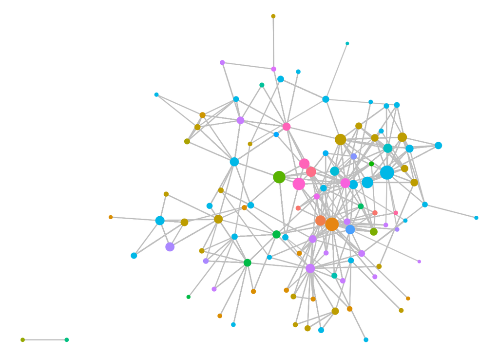

Легенда была извлечена из графика намеренно, так как она занимала слишком много места и перекрывала сеть. Но даже визуально видно, что разные должности (отмеченные разным цветом) имеют тенденции занимать определённые места в сети.

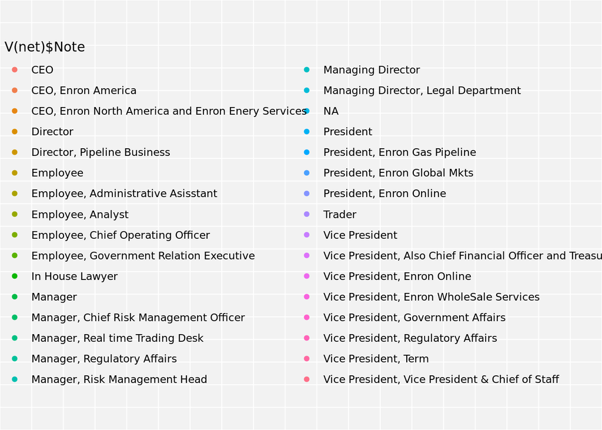

Итак, мы имеем сеть с ярко выраженными сообществами, в которых более крупные узлы кажутся более связанными между собой. Также можно визуально выделить сообщество из двух узлов, не связанных с остальными вершинами.

### Выявление значимых вершин

**Использованные меры центральности: битвинность, степень узлов**

Теперь проанализируем сеть с точки зрения показателей центральностей. Как уже было сказано, кажется, что определённые должности имеют тенденции занимать схожие места в сети. Отфильтруем сеть по показателям степени узлов и битвинности и визуализируем её.

**Степень узлов**

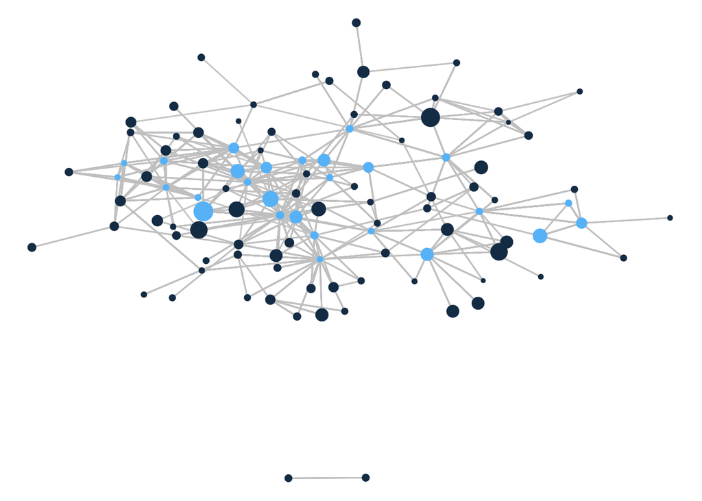

Казалось бы, отмеченными оказались и не самые крупные узлы. Скорее всего, такие вершины получают письма в копии и не занимают высокие должности, так как им направляют не так много писем.

**Битвинность**

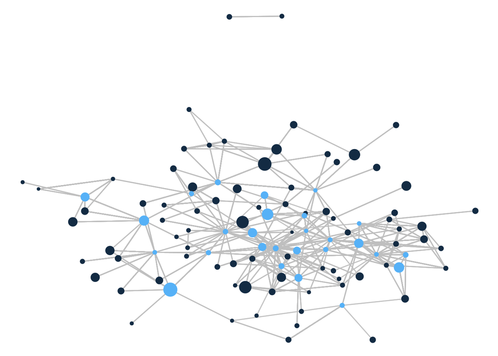

Здесь ситуация кажется более ясной. Очевидно, что узлы с более высокой битвинностью пропускают через себя больше писем и, соотвественно, связывают между собой сообщества.

### Выявление сообществ

**Использованные меры выделения сообществ: walktrap**

Так как у нас направленный граф, то для выделения сообществ возможно использовать ограниченное количество инструментов.

```
## IGRAPH clustering walktrap, groups: 18, mod: 0.6
## + groups:
##   $`1`
##    [1]  1  5 41 54 69 74 78 85 87 88
##
##   $`2`
##   [1]  2 13 19 33 47 65 76
##
##   $`3`
##   [1]  83 104
##
##   $`4`
##   + ... omitted several groups/vertices
```

Всего получилось выделить 18 сообществ. Визуализируем их на сети.

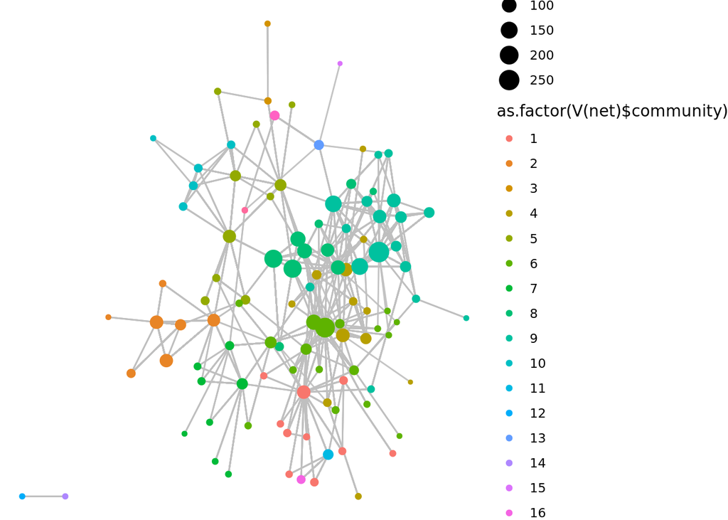

### Исследовательские вопросы

**Вопрос 1: Сответствуют ли степени узлов их группам?**

Исходя из предыдущего рассуждения, я могу предположить, что вершины с похожими степенями состоят в одной группе.

```
## [1] 0.7516407
```

Показатель ассортативности очень высок, поэтому моя гипотеза подтверждается. Если рассуждать логически, то можно прийти к выводу, что такой результат мы получили из-за того, что люди общаются больше с теми, кто соответсвует их должности: например, собираются на совет директоров или устаивают собрание отдела.

**Вопрос 2: Правда ли, что вершины с самой большой битвинностью это менеджеры?**

Как уже было замечено ранее, вершины с самой большой битвинность находятся на пересечении сообществ. Если обратиться к самому первому графику с разделением должностей по цветам, то можно предположить, что именно менеджеры являются связующими элементами между группами.

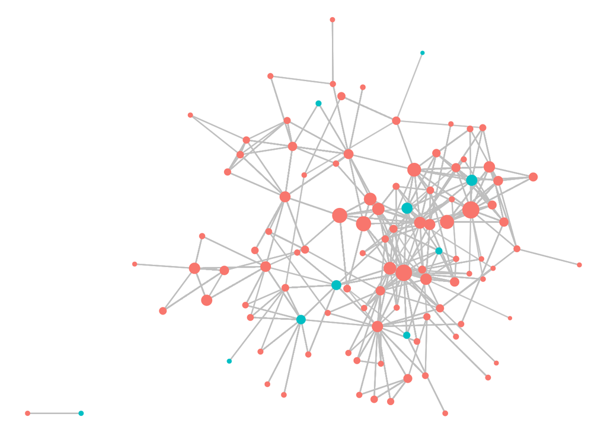

Чисто визуально моя гипотеза немного похожа на правдивую, однако перепроверим эти догадки с помощью теста.

```
##
##  Pearson's product-moment correlation
##
## data:  x and y
## t = 0.90899, df = 104, p-value = 0.3655
## alternative hypothesis: true correlation is not equal to 0
## 95 percent confidence interval:
##  -0.1037305  0.2748818
## sample estimates:
##        cor
## 0.08878167
```

Ну нет, так нет. Посмотрим, какие должности занимают сотрудники с самой высокой битвинностью.

```
## # A tibble: 32 × 2
##    Note                                                  m
##    <chr>                                             <dbl>
##  1 CEO, Enron North America and Enron Enery Services 1871.
##  2 Vice President, Enron WholeSale Services          1186.
##  3 Employee, Government Relation Executive            948.
##  4 Managing Director, Legal Department                759.
##  5 CEO, Enron America                                 685.
##  6 Manager                                            530.
##  7 President, Enron Global Mkts                       425.
##  8 Vice President, Vice President & Chief of Staff    389.
##  9 Vice President, Regulatory Affairs                 262.
## 10 Vice President, Government Affairs                 184.
## # … with 22 more rows
```

Моя первоначальная гипотеза не подтвердилась, так как “связующими узлами” между группами оказались именно руководящие должности (хотя некоторые из них тоже называются менеджерами).

## Место сотрудника в сети

```
## [1] "Jeffrey Shankman"
```

Посмотрим его конкретное место на общем графике сети.

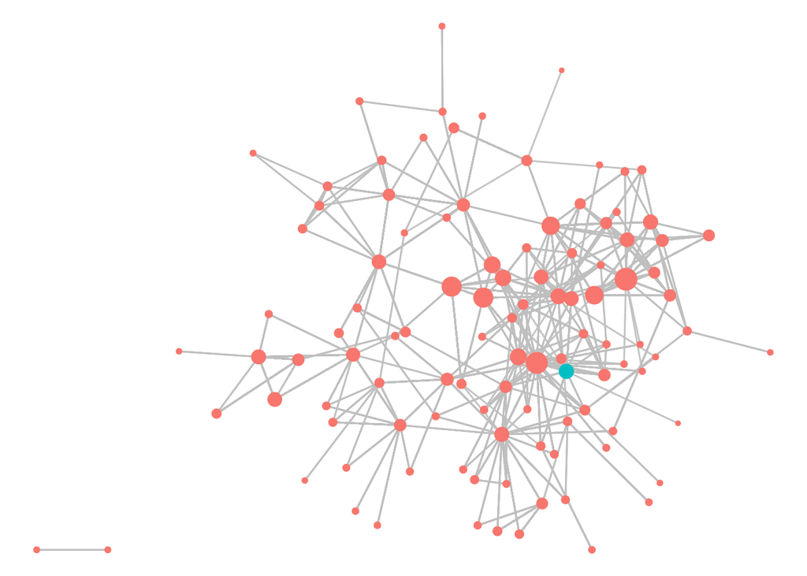

```
## [1] -0.4828418
```

Оказалось, что этот работник совсем не похож на тех, с кем он имеет связи. Теперь сравним его степень со степенями связанных с ним сотрудников.

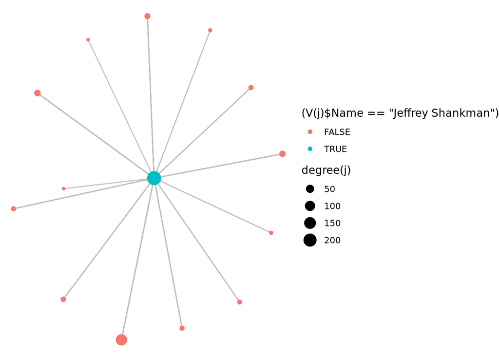

Даже без дополнительных расчётов видно, что его степень явно отличается от тех, с кем у него есть связь, кроме одной вершины. Посмотрим, чем же они ещё похожи. Мне кажется, что они могут находится в одной группе.

```
##  [1]   3  23   2   6 243   3   8  10   2   8 135   8  20  15
```

```
##               Name                         Note community
## 1 Jeffrey Shankman President, Enron Global Mkts         4
## 2               NA                           NA         4
```

Теперь сравним меры центарльности этой вершины по сравнению со всеми остальными вершинами.

```
##              Email             Name                         Note community
## 1 jeffrey.shankman Jeffrey Shankman President, Enron Global Mkts         4
##   manager betweenness degree
## 1   FALSE    425.2303    243
```

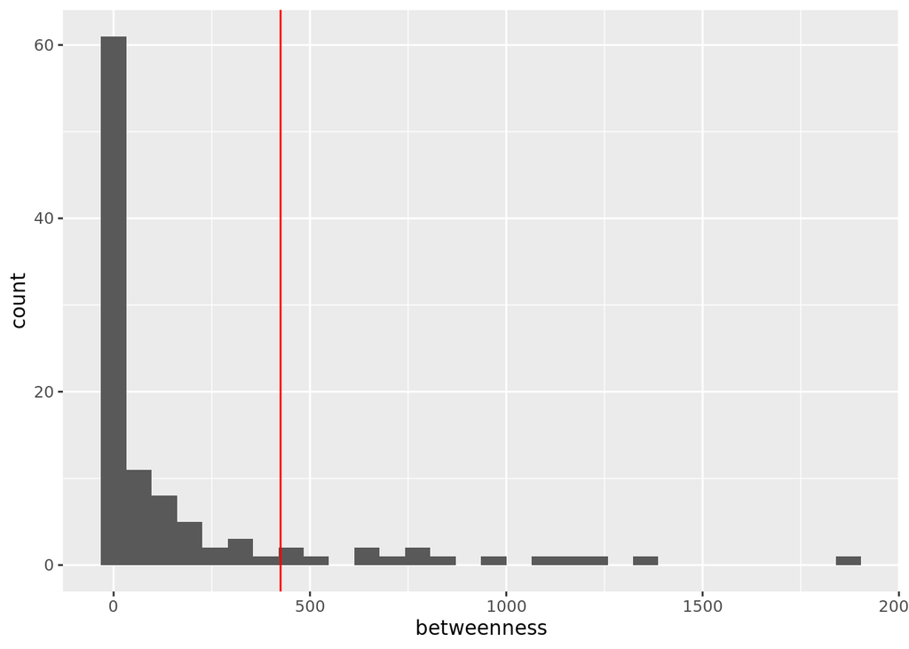

```
##              Email             Name                         Note community
## 1 jeffrey.shankman Jeffrey Shankman President, Enron Global Mkts         4
##   manager betweenness degree
## 1   FALSE    425.2303    243
```

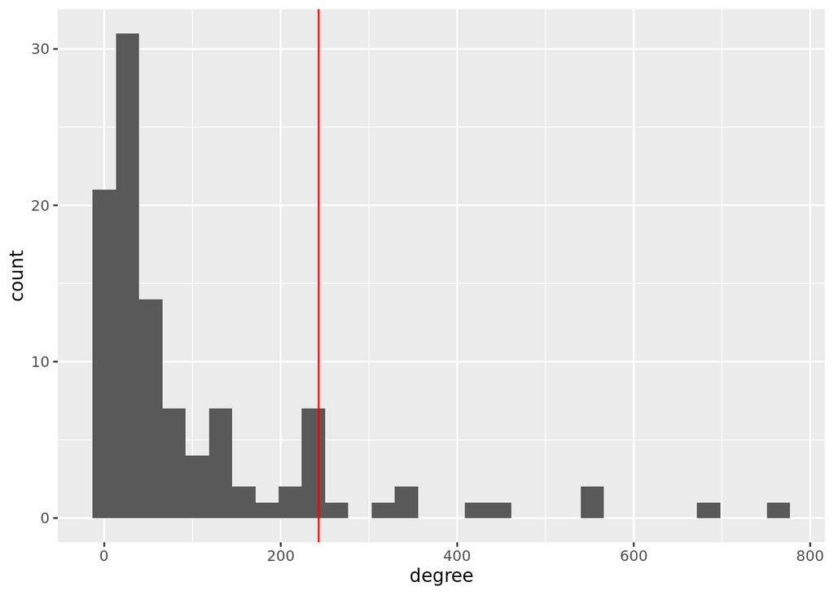

Очевидно, что показатель его степени и битвинности гораздо выше большинства работников (что скорее всего связано с его высокой должностью), поэтому можно утверждать, что через него проходит огромное количество писем (даже при рассмотрении одного месяца).